# Assignment 2

In this assignment you will create a coordinate-based multilayer perceptron in numpy from scratch. For each input image coordinate $(x,y)$, the model predicts the associated color $(r,g,b)$.

[figure not shown]

You will then compare the following input feature mappings $\gamma (\mathbf{v})$.

- No mapping: $\gamma(\mathbf{v})= \mathbf{v}$.
- Basic mapping: $\gamma(\mathbf{v})=\left[ \cos(2 \pi \mathbf{v}),\sin(2 \pi \mathbf{v}) \right]^\mathrm{T}$.
- Gaussian Fourier feature mapping: $\gamma(\mathbf{v})= \left[ \cos(2 \pi \mathbf B \mathbf{v}), \sin(2 \pi \mathbf B \mathbf{v}) \right]^\mathrm{T}$, where each entry in $\mathbf B \in \mathbb R^{m \times d}$ is sampled from $\mathcal N(0,\sigma^2)$.

Some notes to help you with that:

- You will implement the mappings in the helper functions `get_B_dict` and `input_mapping`.
- The basic mapping can be considered a case where $\mathbf B \in \mathbb R^{2 \times 2}$ is the indentity matrix.
- For this assignment, $d$ is 2 because the input coordinates in two dimensions.
- You can experiment with $m$, like $m=256$.
- You should show results for $\sigma$ value of 1.

Source: https://bmild.github.io/fourfeat/ This assignment is inspired by and built off of the authors' demo.

## Setup

### (Optional) Colab Setup

If you aren't using Colab, you can delete the following code cell. Replace the path below with the path in your Google Drive to the uploaded assignment folder. Mounting to Google Drive will allow you access the other .py files in the assignment folder and save outputs to this folder

```python
# you will be prompted with a window asking to grant permissions
# click connect to google drive, choose your account, and click allow
from google.colab import drive
drive.mount("/content/drive")
```

[output not shown]

```python
# TODO: fill in the path in your Google Drive in the string below
# Note: do not escape slashes or spaces in the path string
import os
datadir = "/content/assignment2"
if not os.path.exists(datadir):
  !ln -s "/content/drive/My Drive/path/to/your/assignment2/" $datadir
os.chdir(datadir)
!pwd
```

[output not shown]

[output not shown]

### Imports

```python
import matplotlib.pyplot as plt
from tqdm.notebook import tqdm
import os, imageio
import cv2
import numpy as np

# imports /content/assignment2/models/neural_net.py if you mounted correctly
from models.neural_net import NeuralNetwork

# makes sure your NeuralNetwork updates as you make changes to the .py file
%load_ext autoreload
%autoreload 2

# sets default size of plots
%matplotlib inline
plt.rcParams['figure.figsize'] = (10.0, 8.0)
```

## Helper Functions

### Image Data and Feature Mappings (Fill in TODOs)

```python
# Data loader - already done for you
def get_image(size=512, \
              image_url='https://bmild.github.io/fourfeat/img/lion_orig.png'):

  # Download image, take a square crop from the center
  img = imageio.imread(image_url)[..., :3] / 255.
  c = [img.shape[0]//2, img.shape[1]//2]
  r = 256
  img = img[c[0]-r:c[0]+r, c[1]-r:c[1]+r]

  if size != 512:
    img = cv2.resize(img, (size, size))

  plt.imshow(img)
  plt.show()

  # Create input pixel coordinates in the unit square
  coords = np.linspace(0, 1, img.shape[0], endpoint=False)
  x_test = np.stack(np.meshgrid(coords, coords), -1)
  test_data = [x_test, img]
  train_data = [x_test[::2, ::2], img[::2, ::2]]

  return train_data, test_data
```

```python
# Create the mappings dictionary of matrix B -  you will implement this
def get_B_dict(size):
  mapping_size = size // 2 # you may tweak this hyperparameter
  B_dict = {}
  B_dict['none'] = None

  # add B matrix for basic, gauss_1.0
  # TODO implement this
  B_dict['basic'] = np.eye(2)
  B_dict['gauss_1.0'] = np.random.normal(0, 1, (mapping_size, 2))
  return B_dict
```

```python
# Given tensor x of input coordinates, map it using B - you will implement
def input_mapping(x, B):
  if B is None:
    # "none" mapping - just returns the original input coordinates
    return x
  else:
    # "basic" mapping and "gauss_X" mappings project input features using B
    # TODO implement this
    x_map = (2.*np.pi*x) @ B.T
    return np.concatenate([np.cos(x_map), np.sin(x_map)], axis=-1)
```

### MSE Loss and PSNR Error (Fill in TODOs)

```python
def mse(y, p):
  # TODO implement this
  # make sure it is consistent with your implementation in neural_net.py
  return np.mean((y - p) ** 2)

def psnr(y, p):
  # TODO implement this
  return -10 * np.log10(2.*mse(y, p))
```

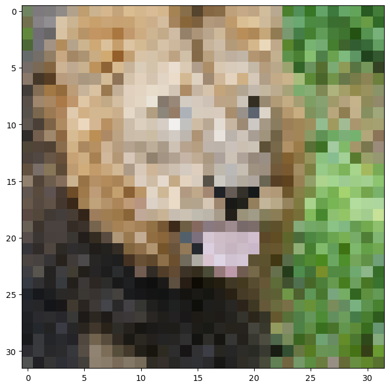

```python
size = 32
train_data, test_data = get_image(size)
```

Some suggested hyperparameter choices to help you start

- hidden layer count: 6
- hidden layer size: 256
- number of epochs: 1000
- learning rate: 5e-2

```python
# TODO: Set the hyperparameters
num_layers = 4
# hidden_size = 256
hidden_size = [256]
epochs = 3000
# learning_rate = 5e-2
learning_rate = [10]
# learning_rate = [30]
output_size = 3
batch_size = [256]
# batch_size = [128]
decay = [0.5]
# decay = [0.1]
B_dict = get_B_dict(size)

print('B_dict items:')
for k,v in B_dict.items():
    print('\t',k,np.array(v).shape)
```

```
B_dict items:
	 none ()
	 basic (2, 2)
	 gauss_1.0 (16, 2)
```

```python
# Apply the input feature mapping to the train and test data - already done for you
def get_input_features(B_dict, mapping):
  # mapping is the key to the B_dict, which has the value of B
  # B is then used with the function `input_mapping` to map x
  y_train = train_data[1].reshape(-1, output_size)
  y_test = test_data[1].reshape(-1, output_size)
  X_train = input_mapping(train_data[0].reshape(-1, 2), B_dict[mapping])
  X_test = input_mapping(test_data[0].reshape(-1, 2), B_dict[mapping])
  return X_train, y_train, X_test, y_test
```

### Plotting and video helper functions (you don't need to change anything here)

```python
def plot_training_curves(train_loss, train_psnr, test_psnr):
  # plot the training loss
  plt.subplot(2, 1, 1)
  plt.plot(train_loss)
  plt.title('MSE history')
  plt.xlabel('Iteration')
  plt.ylabel('MSE Loss')

  # plot the training and testing psnr
  plt.subplot(2, 1, 2)
  plt.plot(train_psnr, label='train')
  plt.plot(test_psnr, label='test')
  plt.title('PSNR history')
  plt.xlabel('Iteration')
  plt.ylabel('PSNR')
  plt.legend()

  plt.tight_layout()
  plt.show()

def plot_reconstruction(p, y, hidden_size, learning_rate, batch_size, decay, mapping):
  p_im = p.reshape(size,size,3)
  y_im = y.reshape(size,size,3)

  plt.figure(figsize=(12,6))

  # plot the reconstruction of the image
  plt.subplot(1,2,1), plt.imshow(p_im), plt.title("reconstruction")

  # plot the ground truth image
  plt.subplot(1,2,2), plt.imshow(y_im), plt.title("ground truth")

  with open('results.txt', 'a') as file:
    print(f'hidden_size {hidden_size}, learning_rate {learning_rate}, batch_size {batch_size}, decay {decay}, mapping {mapping}')
    print("Final Test MSE", mse(y, p))
    print("Final Test psnr",psnr(y, p))
    print(f'hidden_size {hidden_size}, learning_rate {learning_rate}, batch_size {batch_size}, decay {decay}, mapping {mapping}', file=file)
    print("Final Test MSE", mse(y, p), file=file)
    print("Final Test psnr",psnr(y, p), file=file)

def plot_reconstruction_progress(predicted_images, y, N=8):
  total = len(predicted_images)
  step = total // N
  plt.figure(figsize=(24, 4))

  # plot the progress of reconstructions
  for i, j in enumerate(range(0,total, step)):
      plt.subplot(1, N+1, i+1)
      plt.imshow(predicted_images[j].reshape(size,size,3))
      plt.axis("off")
      plt.title(f"iter {j}")

  # plot ground truth image
  plt.subplot(1, N+1, N+1)
  plt.imshow(y.reshape(size,size,3))
  plt.title('GT')
  plt.axis("off")
  plt.show()

def plot_feature_mapping_comparison(outputs, gt):
  # plot reconstruction images for each mapping
  plt.figure(figsize=(24, 4))
  N = len(outputs)
  for i, k in enumerate(outputs):
      plt.subplot(1, N+1, i+1)
      plt.imshow(outputs[k]['pred_imgs'][-1].reshape(size, size, -1))
      plt.title(k)
  plt.subplot(1, N+1, N+1)
  plt.imshow(gt)
  plt.title('GT')
  plt.show()

  # plot train/test error curves for each mapping
  iters = len(outputs[k]['train_psnrs'])
  plt.figure(figsize=(16, 6))
  plt.subplot(121)
  for i, k in enumerate(outputs):
      plt.plot(range(iters), outputs[k]['train_psnrs'], label=k)
  plt.title('Train error')
  plt.ylabel('PSNR')
  plt.xlabel('Training iter')
  plt.legend()
  plt.subplot(122)
  for i, k in enumerate(outputs):
      plt.plot(range(iters), outputs[k]['test_psnrs'], label=k)
  plt.title('Test error')
  plt.ylabel('PSNR')
  plt.xlabel('Training iter')
  plt.legend()
  plt.show()

# Save out video
def create_and_visualize_video(outputs, size=size, epochs=epochs, filename='training_convergence.mp4'):
  all_preds = np.concatenate([outputs[n]['pred_imgs'].reshape(epochs,size,size,3)[::25] for n in outputs], axis=-2)
  data8 = (255*np.clip(all_preds, 0, 1)).astype(np.uint8)
  f = os.path.join(filename)
  imageio.mimwrite(f, data8, fps=20)

  # Display video inline
  from IPython.display import HTML
  from base64 import b64encode
  mp4 = open(f, 'rb').read()
  data_url = "data:video/mp4;base64," + b64encode(mp4).decode()

  N = len(outputs)
  if N == 1:
    return HTML(f'''
    <video width=256 controls autoplay loop>
          <source src="{data_url}" type="video/mp4">
    </video>
    ''')
  else:
    return HTML(f'''
    <video width=1000 controls autoplay loop>
          <source src="{data_url}" type="video/mp4">
    </video>
    <table width="1000" cellspacing="0" cellpadding="0">
      <tr>{''.join(N*[f'<td width="{1000//len(outputs)}"></td>'])}</tr>
      <tr>{''.join(N*['<td style="text-align:center">{}</td>'])}</tr>
    </table>
    '''.format(*list(outputs.keys())))
```

### Experiment Runner (Fill in TODOs)

```python
def NN_experiment(X_train, y_train, X_test, y_test, input_size, num_layers,\
                  hidden_size, output_size, epochs,\
                  learning_rate, batch_size, decay, opt='SGD'):

    # Initialize a new neural network model
    hidden_sizes = [hidden_size] * (num_layers - 1)
    net = NeuralNetwork(input_size, hidden_sizes, output_size, num_layers, opt)

    # Variables to store performance for each epoch
    train_loss = np.zeros(epochs)
    train_psnr = np.zeros(epochs)
    test_psnr = np.zeros(epochs)
    predicted_images = np.zeros((epochs, y_test.shape[0], y_test.shape[1]))

    # For each epoch...
    for epoch in tqdm(range(epochs)):
        # Shuffle the dataset
        # TODO implement this
        indices = np.arange(X_train.shape[0])
        np.random.shuffle(indices)
        X_train_shuffled = X_train[indices]
        y_train_shuffled = y_train[indices]
        # Training
        # Run the forward pass of the model to get a prediction and record the psnr
        # TODO implement this
        for i in range(X_train.shape[0] // batch_size):
            y_pred = net.forward(X_train_shuffled[i*batch_size : (i+1)*batch_size])
            train_psnr[epoch] += psnr(y_train_shuffled[i*batch_size : (i+1)*batch_size], y_pred)
            # Run the backward pass of the model to compute the loss, record the loss, and update the weights
            # TODO implement this
            train_loss[epoch] += net.backward(y_train_shuffled[i*batch_size : (i+1)*batch_size])
            net.update(lr=learning_rate)
        # Testing
        # No need to run the backward pass here, just run the forward pass to compute and record the psnr
        # TODO implement this
        if epoch%50 == 49:
            learning_rate *= 0.5
        test_pred = net.forward(X_test)
        test_psnr[epoch] = psnr(y_test, test_pred)
        predicted_images[epoch] = test_pred


    return net, train_psnr, test_psnr, train_loss, predicted_images
```

# Low Resolution Reconstruction

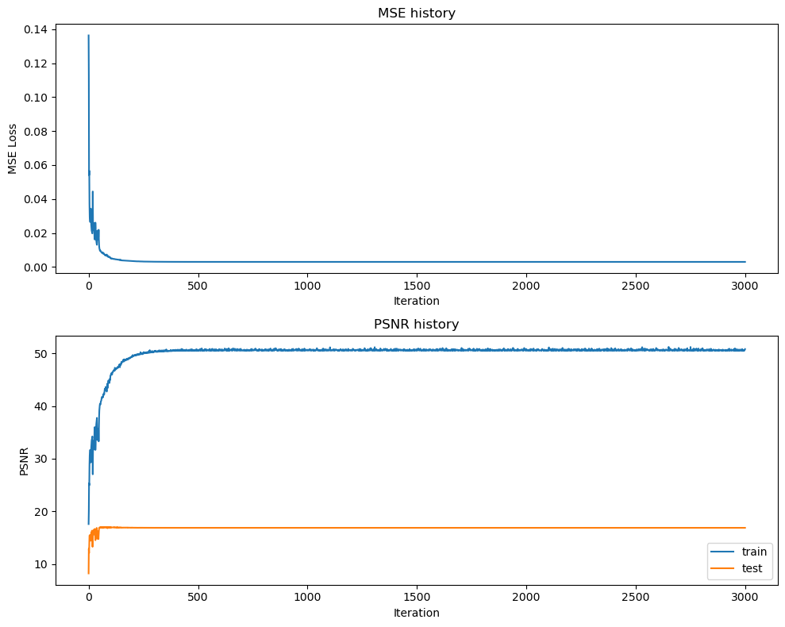

```
hidden_size 256, learning_rate 10, batch_size 256, decay 0.5, mapping gauss_1.0
Final Test MSE 0.010273276612813612
Final Test psnr 16.872610224808792
```

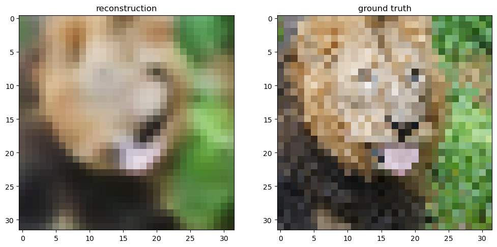

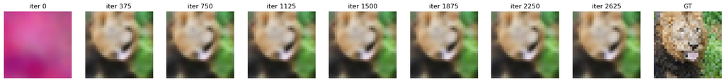

```python
# get input features
# TODO implement this by using the get_B_dict() and get_input_features() helper functions
B_dict = get_B_dict(64)
mappings = ['gauss_1.0']
for mapping in mappings:
    X_train, y_train, X_test, y_test = get_input_features(B_dict, mapping)
    # run NN experiment on input features
    # TODO implement by using the NN_experiment() helper function
    for hs in hidden_size:
        for lr in learning_rate:
            for bs in batch_size:
                for d in decay:
                    net, train_psnr, test_psnr, train_loss, predicted_images =  NN_experiment(X_train, y_train, X_test, y_test, X_train.shape[1], num_layers,
                                                                                    hs, output_size, epochs, lr, bs, d, 'SGD')
                    # plot results of experiment
                    plot_training_curves(train_loss, train_psnr, test_psnr)
                    plot_reconstruction(net.forward(X_test), y_test, hs, lr, bs, d, mapping)
                    plot_reconstruction_progress(predicted_images, y_test)
```

```python
def train_wrapper(mapping, size, num_layers, hidden_size, output_size, epochs,  learning_rate, batch_size, decay, opt='SGD'):
    # TODO implement me
    # makes it easy to run all your mapping experiments in a for loop
    # this will similar to what you did previously in the last two sections
    X_train, y_train, X_test, y_test = get_input_features(B_dict, mapping)
    # run NN experiment on input features
    # TODO implement by using the NN_experiment() helper function
    net, train_psnr, test_psnr, train_loss, predicted_images =  NN_experiment(X_train, y_train, X_test, y_test, X_train.shape[1], num_layers,
                                                                    hs, output_size, epochs, lr, bs, d, 'SGD')
    # plot results of experiment
    plot_training_curves(train_loss, train_psnr, test_psnr)
    plot_reconstruction(net.forward(X_test), y_test, hs, lr, bs, d, mapping)
    plot_reconstruction_progress(predicted_images, y_test)

    return {
        'net': net,
        'train_psnrs': train_psnr,
        'test_psnrs': test_psnr,
        'train_loss': train_loss,
        'pred_imgs': predicted_images
    }
```

[output not shown]

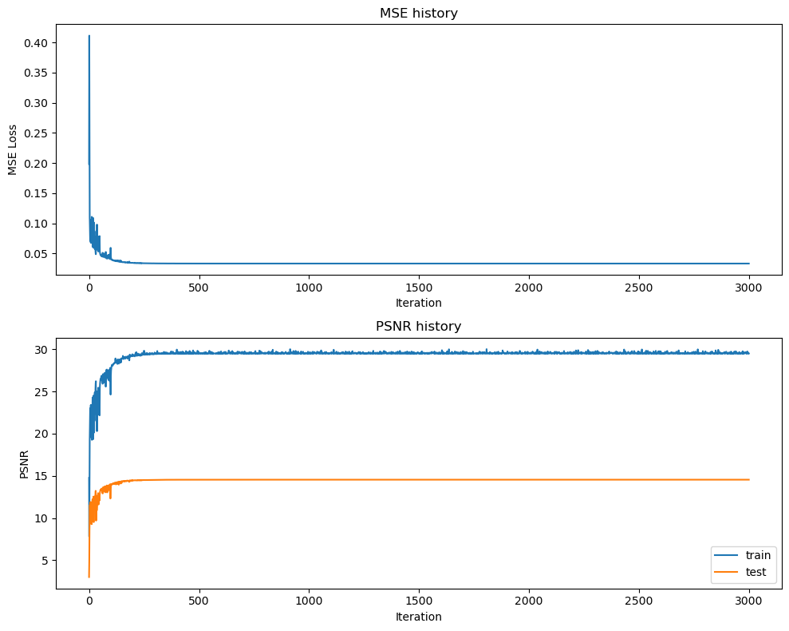

```
hidden_size 256, learning_rate 10, batch_size 256, decay 0.5, mapping none
Final Test MSE 0.017564721265560284
Final Test psnr 14.543287419694074
```

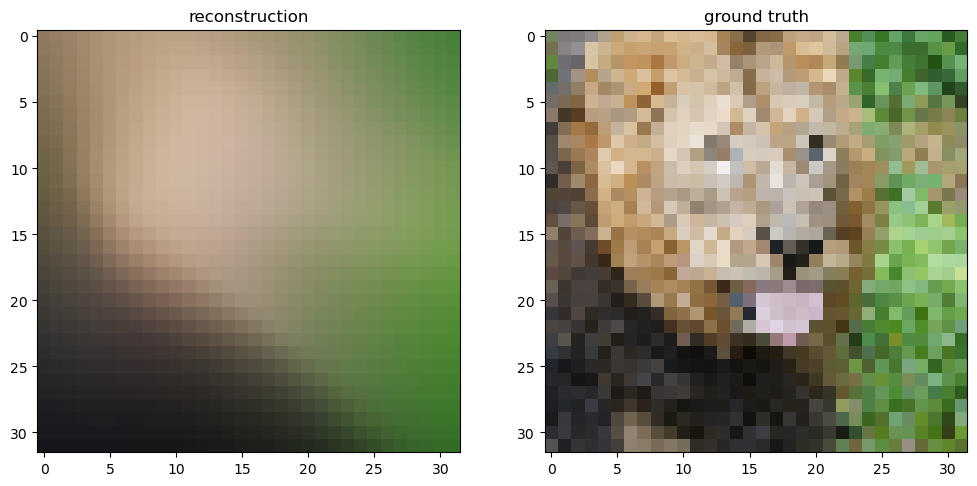

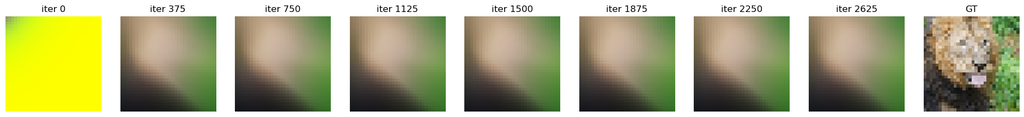

```python
outputs = {}
print(B_dict)
for hs in hidden_size:
  for lr in learning_rate:
    for bs in batch_size:
      for d in decay:
        for k in tqdm(B_dict):
            if k!='none':
              continue
            outputs[k] = train_wrapper(k, size, num_layers, hs, output_size, epochs, lr, bs, d, opt='SGD')
```

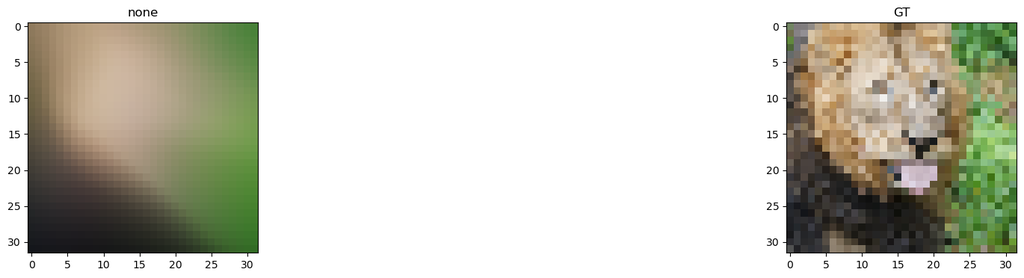

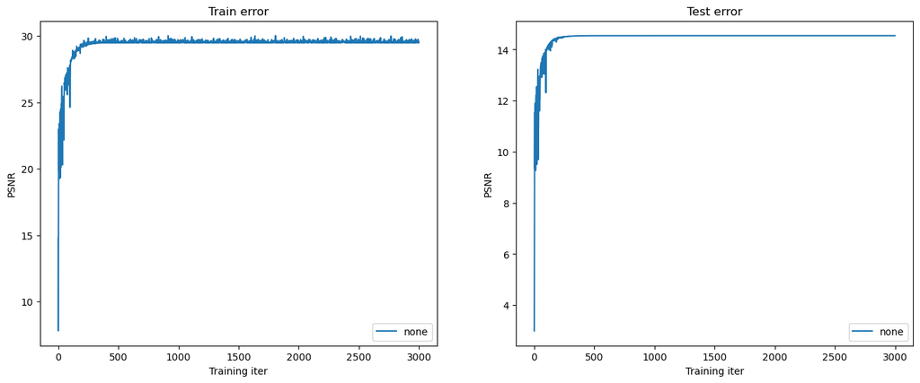

```python
# if you did everything correctly so far, this should output a nice figure you can use in your report
plot_feature_mapping_comparison(outputs, y_test.reshape(size,size,3))
```

# High Resolution Reconstruction

Repeat the previous experiment, but at the higher resolution. The reason why we have you first experiment with the lower resolution since it is faster to train and debug. Additionally, you will see how the mapping strategies perform better or worse at the two different input resolutions.

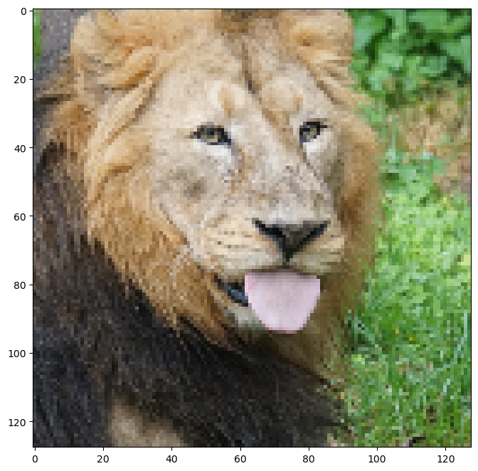

```python
# load hi-res image
size = 128
train_data, test_data = get_image(size)
```

[output not shown]

[output cut: 10 more lines]

[output not shown]

```
basic
```

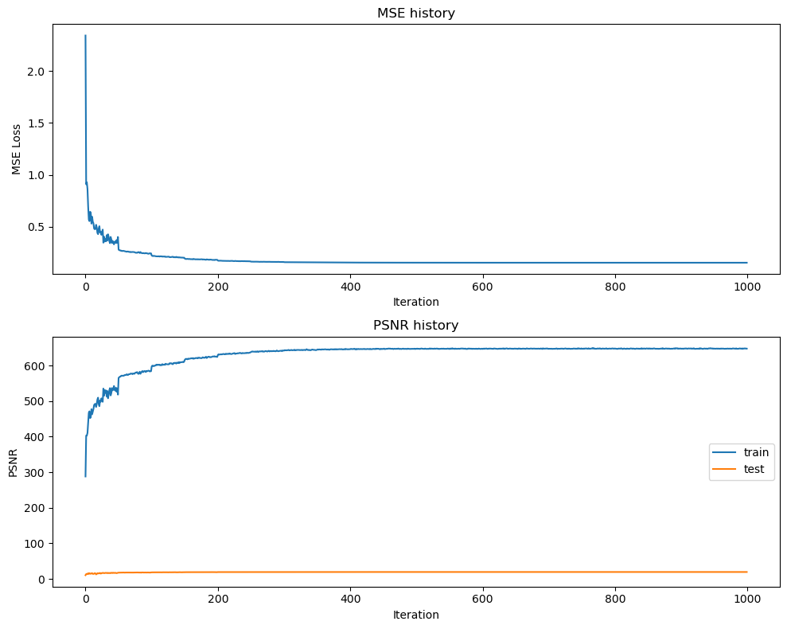

[output not shown]

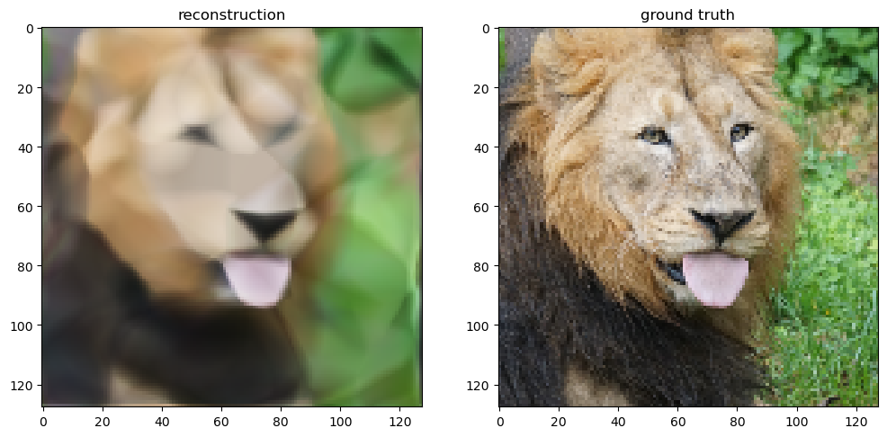

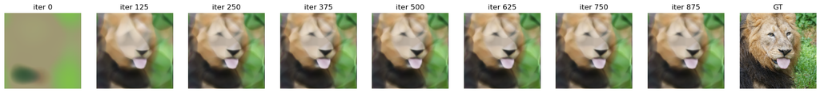

```python
outputs = {}
print(B_dict)
for hs in hidden_size:
  for lr in learning_rate:
    for bs in batch_size:
      for d in decay:
        for k in tqdm(B_dict):
            if k!='basic':
              continue
            print(k)
            outputs[k] = train_wrapper(k, size, num_layers, hs, output_size, epochs, lr, bs, d, opt='SGD')
```

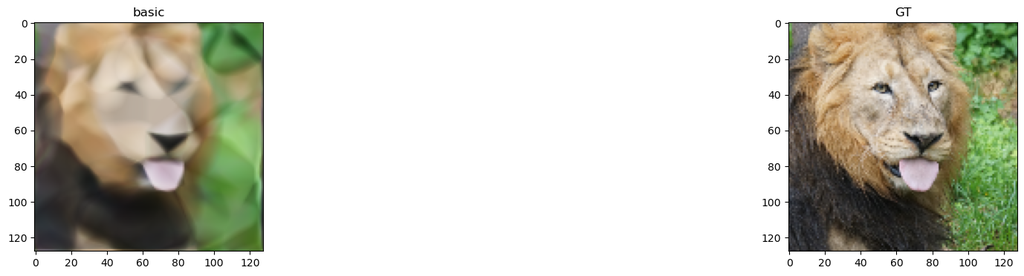

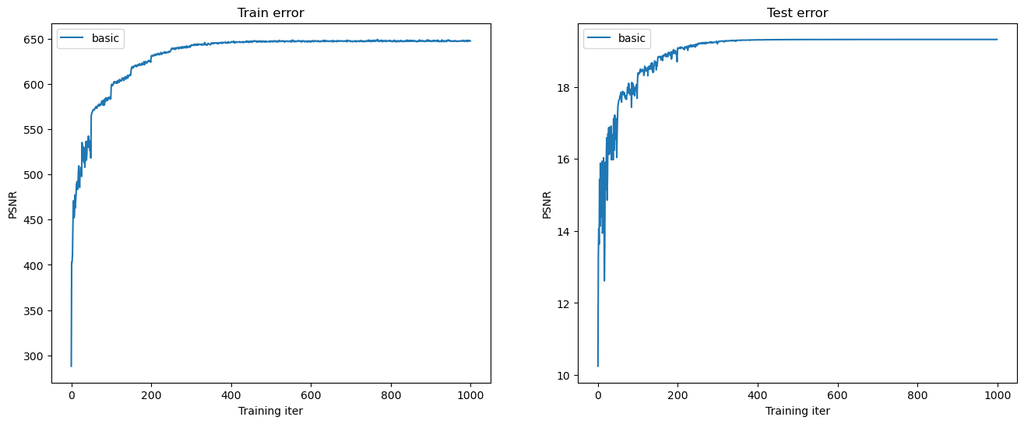

```python
X_train, y_train, X_test, y_test = get_input_features(get_B_dict(size), "none")  # for getting y_test

# if you did everything correctly so far, this should output a nice figure you can use in your report
plot_feature_mapping_comparison(outputs, y_test.reshape(size,size,3))
```

#### High Resolution Reconstruction - Image of your Choice

When choosing an image select one that you think will give you interesting results or a better insight into the performance of different feature mappings and explain why in your report template.

[figure not shown]

```python
size = 128
# TODO pick an image and replace the url string
train_data, test_data = get_image(size, image_url="https://pbs.twimg.com/media/GNZUoggW8AEleRs.png")
```

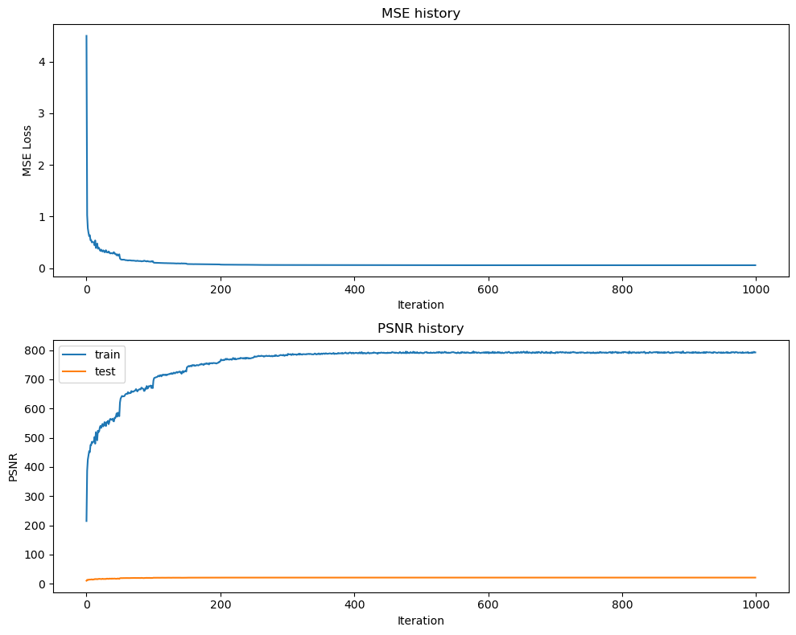

[output not shown]

[figure not shown]

[figure not shown]

```python
# get input features
# TODO implement this by using the get_B_dict() and get_input_features() helper functions


# run NN experiment on input features
# TODO implement by using the NN_experiment() helper function

outputs = {}
for hs in hidden_size:
  for lr in learning_rate:
    for bs in batch_size:
      for d in decay:
        for k in tqdm(B_dict):
            if k!='gauss_1.0':
              continue
            X_train, y_train, X_test, y_test = get_input_features(B_dict, k)
            net, train_psnr, test_psnr, train_loss, predicted_images =  NN_experiment(X_train, y_train, X_test, y_test, X_train.shape[1], num_layers,
                                                                    hs, output_size, epochs, lr, bs, d, 'SGD')
            plot_training_curves(train_loss, train_psnr, test_psnr)
            plot_reconstruction(net.forward(X_test), y_test, hs, lr, bs, d, k)
            plot_reconstruction_progress(predicted_images, y_test)
```

# Reconstruction Process Video (Optional)

(For Fun!) Visualize the progress of training in a video

```python
# requires installing this additional dependency
!pip install imageio-ffmpeg
```

```python
# single video example
create_and_visualize_video({"gauss": {"pred_imgs": predicted_images}}, filename="training_high_res_gauss.mp4")
```

```python
# multi video example
create_and_visualize_video(outputs, epochs=1000, size=32)
```

# Extra Credit - Adam Optimizer

#### Low Resolution Reconstruction - Adam - None Mapping

```python
# load low-res image
size = 32
train_data, test_data = get_image(size)
```

[output not shown]

```python
# get input features
# TODO implement this by using the get_B_dict() and get_input_features() helper functions

# run NN experiment on input features
# TODO implement by using the NN_experiment() helper function

# plot results of experiment
plot_training_curves(train_loss, train_psnr, test_psnr)
plot_reconstruction(net.forward(X_test), y_test)
plot_reconstruction_progress(predicted_images, y_test)
```

[output not shown]

#### Low Resolution Reconstruction - Adam - Various Input Mapping Stategies

```python
# start training
outputs = {}
for k in tqdm(B_dict):
  print("training", k)
  outputs[k] = train_wrapper(k, size, num_layers, hidden_size, output_size, epochs, learning_rate, opt='Adam')
```

#### High Resolution Reconstruction - Adam - Various Input Mapping Stategies

Repeat the previous experiment, but at the higher resolution. The reason why we have you first experiment with the lower resolution since it is faster to train and debug. Additionally, you will see how the mapping strategies perform better or worse at the two different input resolutions.

```python
# load image
size = 128
train_data, test_data = get_image(size)

# start training
outputs = {}
for k in tqdm(B_dict):
  print("training", k)
  outputs[k] = train_wrapper(k, size, num_layers, hidden_size, output_size, epochs, learning_rate, opt='Adam')
```

[output not shown]

```python
X_train, y_train, X_test, y_test = get_input_features(get_B_dict(size), "none")  # for getting y_test

# if you did everything correctly so far, this should output a nice figure you can use in your report
plot_feature_mapping_comparison(outputs, y_test.reshape(size,size,3))
```

[output not shown]